# Tarification en assurance

Franck Armel Tadi Nguement

2026-05-05

*Description des variables:*

*1.Caractéristiques générales*

*model_name* : Nom du modèle d’avion.

*engine_type* : Type de moteur (turbopropulseur, réacteur, etc.).

*engine_power* : Puissance du moteur (en chevaux ou en livres de poussée).

*2.Performances et capacités*

*max_speed* : Vitesse maximale (en nœuds).

*cruise_speed* : Vitesse de croisière (en nœuds).

*stall_speed* : Vitesse minimale pour éviter le décrochage (en nœuds).

*fuel_tank* : Capacité du réservoir de carburant (en gallons).

*all_eng_roc* : Taux de montée avec tous les moteurs (en pieds).

*out_eng_roc* : Taux de montée avec un moteur en panne (en pieds).

*3.Exigences opérationnelles*

*takeoff_distance* : Distance minimale requise pour le décollage (en pieds).

*landing_distance* : Distance minimale requise pour l’atterrissage (en pieds).

*4.Dimensions et masse*

*empty_weight* : Poids à vide de l’avion (en livres).

*longueur* : Longueur de l’avion (en pouces).

*wing_span* : Envergure des ailes (en pouces).

*5.Autonomie et coût*

*portée* : Portée de l’avion (en miles nautiques).

*prix* : Prix de l’avion (variable cible pour la prévision).

#Introduction

Dans un contexte où la prévision des prix des avions est essentielle pour les acteurs du marché aéronautique, notre étude vise à construire et comparer plusieurs modèles de prédiction basés sur un ensemble de caractéristiques techniques des avions. Le jeu de données que nous utilisons contient des informations détaillées sur différents modèles d’avions, notamment la puissance du moteur, la vitesse de croisière, la distance de décollage et d’atterrissage, ainsi que leur prix. Cependant, avant toute analyse, il est essentiel de traiter **les valeurs manquantes** présentes dans le jeu de données afin de garantir la fiabilité des modèles prédictifs. Pour cela, nous avons choisi de supprimer les observations incomplètes afin de travailler sur un ensemble propre et cohérent.

Les variables disponibles sont cruciales pour comprendre les facteurs qui influencent le prix d’un avion. Par exemple, la puissance du moteur et la vitesse de croisière peuvent être des indicateurs clés de la performance d’un avion, ce qui peut influencer son coût. De même, la distance de décollage et d’atterrissage reflète les capacités opérationnelles de l’appareil, tandis que le poids à vide et la capacité du réservoir de carburant peuvent impacter son autonomie et son efficacité énergétique. Enfin, l’envergure des ailes et la longueur de l’appareil sont des caractéristiques physiques qui peuvent affecter à la fois les performances et les coûts de fabrication.

|  | engine_type | engine_power | max_speed | cruise_speed | stall_speed | fuel_tank | all_eng_roc | out_eng_roc | takeoff_distance | landing_distance | empty_weight | length | wing_span | range | price |
| --- | --- | --- | --- | --- | --- | --- | --- | --- | --- | --- | --- | --- | --- | --- | --- |
| 1 | Piston | 145 | 104 | 91 | 46 | 36 | 450 | 900 | 1300 | 2050 | 1180 | 303 | 449 | 370 | 1300000 |
| 2 | Piston | 85 | 89 | 83 | 44 | 15 | 600 | 720 | 800 | 1350 | 820 | 247 | 433 | 190 | 1230000 |
| 3 | Piston | 90 | 90 | 78 | 37 | 19 | 650 | 475 | 850 | 1300 | 810 | 257 | 420 | 210 | 1600000 |
| 4 | Piston | 85 | 88 | 78 | 37 | 19 | 620 | 500 | 850 | 1300 | 800 | 257 | 420 | 210 | 1300000 |
| 5 | Piston | 65 | 83 | 74 | 33 | 14 | 370 | 632 | 885 | 1220 | 740 | 257 | 420 | 175 | 1250000 |

L’objectif de notre étude est d’identifier les variables les plus influentes dans la détermination du prix et de sélectionner le modèle le plus performant pour la prédiction. Nous adopterons une approche combinant statistique et machine learning en testant plusieurs méthodes :

1. Régression linéaire avec sélection de variables via le critère AIC pour identifier les facteurs les plus pertinents.
2. Arbres de décision (CART), optimisés par validation croisée pour capturer d’éventuelles relations non linéaires entre les variables.
3. Méthodes de régularisation Ridge et Lasso, qui permettent de limiter la colinéarité et de sélectionner les variables les plus significatives.

Après calibration des modèles sur un échantillon d’apprentissage, nous évaluerons leur performance sur un jeu de test indépendant afin d’identifier le modèle offrant la meilleure précision prédictive. Enfin, nous analyserons l’importance des variables pour mieux comprendre les principaux déterminants du prix des avions, ce qui pourra être utile aux constructeurs et aux acheteurs dans leur processus de prise de décision.

#1. Calibrage des Modèles

##1.1 Régression linéaire avec sélection AIC

La régression linéaire est un modèle simple mais efficace pour établir des relations entre le prix des avions et les autres variables. Nous utiliserons un critère d’information d’Akaike (AIC) pour sélectionner les variables explicatives les plus pertinentes. L’approche ascendante (forward selection) commence avec un modèle de départ (vide) et ajoute progressivement les variables qui réduisent le plus l’AIC jusqu’à ce qu’aucune amélioration significative ne soit possible.

L’algorithme a d’abord retenue la première variable cruise_speed (vitesse de croisière), qui réduit fortement l’AIC (de 10580 à 9920) puis retient la variable max_speed (vitesse maximale), réduisant encore l’AIC à 9879. Finalement, range (autonomie) est la dernière variable ajoutée, avec un AIC final de 9783.

Le modèle final inclut 9 variables : cruise_speed, max_speed, engine_type, stall_speed, landing_distance, length, wing_span, empty_weight et range.

Le modèle obtenu après sélection par AIC est globalement performant, bien ajusté et composé majoritairement de variables significatives. De plus, le test global de Fisher est très significatif (p-value < 2.2e-16), confirmant que l’ensemble du modèle a une forte capacité explicative. Le coefficient de détermination R^2 est de 0.8823, ce qui indique que le modèle explique environ 88 % de la variabilité du prix des avions à partir des variables explicatives retenues. Cependant, les effets très élevés de certaines variables, malgré leur significativité, soulèvent des soupçons de colinéarité. La colinéarité se manifeste souvent par des coefficients instables et très larges, accompagnés d’un écart-type élevé.

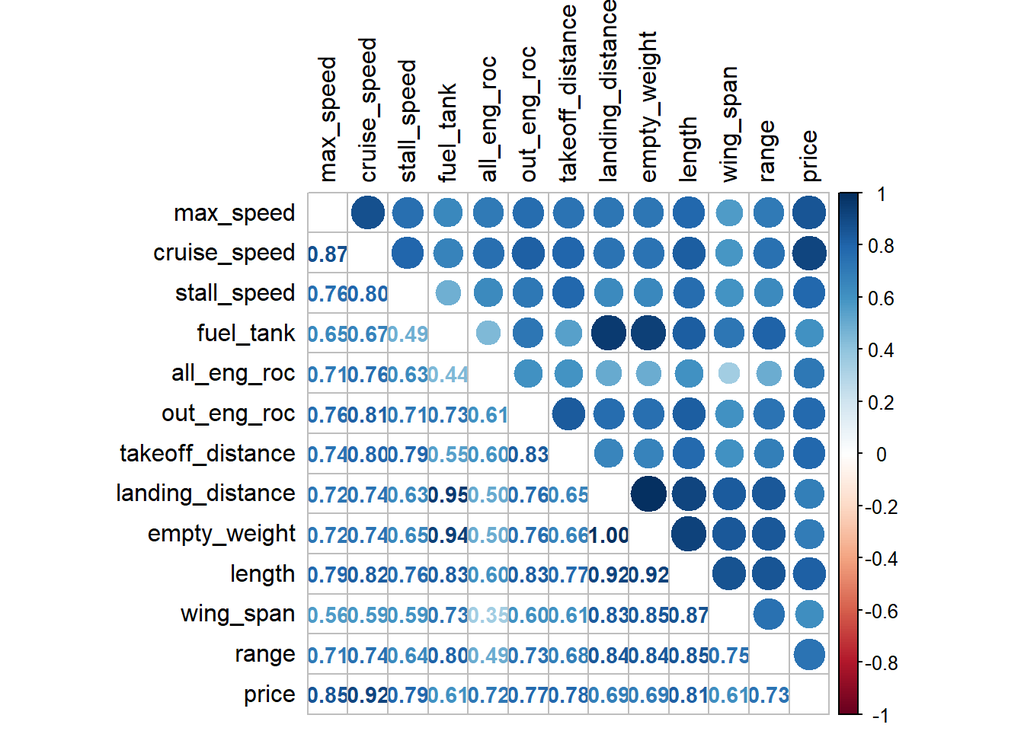

##1.2 Arbres de décision (CART)

L’algorithme CART (Classification and Regression Trees) est une méthode d’apprentissage supervisé qui produit un arbre de décision pour effectuer des prédictions. Il est utilisé ici pour prédire la variable price en fonction des autres variables explicatives Les arbres de décision permettent de capturer des relations non linéaires entre les variables explicatives et la variable cible. Nous choisirons la profondeur optimale et le paramètre de complexité (cp) en minimisant l’erreur de prédiction par validation croisée. L’objectif consiste à minimiser le critère de division pas à pas c’est-à-dire diminuer la déviance.

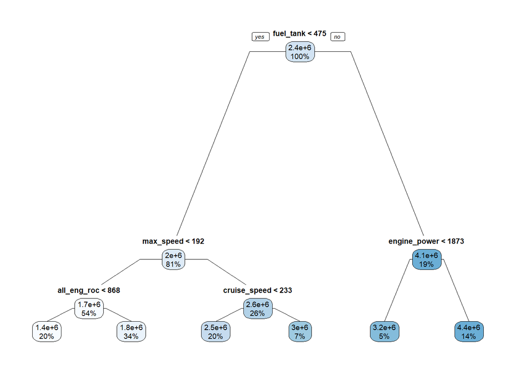

```
##
## Regression tree:
## rpart(formula = price ~ ., data = dtrain)
##
## Variables actually used in tree construction:
## [1] all_eng_roc  cruise_speed engine_power fuel_tank    max_speed
##
## Root node error: 4.0618e+14/382 = 1.0633e+12
##
## n= 382
##
##         CP nsplit rel error  xerror     xstd
## 1 0.653583      0   1.00000 1.00793 0.073415
## 2 0.154665      1   0.34642 0.37801 0.023862
## 3 0.053506      2   0.19175 0.20233 0.017762
## 4 0.026602      3   0.13825 0.15888 0.013109
## 5 0.011434      4   0.11164 0.14245 0.012776
## 6 0.010000      5   0.10021 0.14226 0.014392
```

L’arbre de décision généré repose sur un processus itératif de partitionnement, visant à réduire la déviance des données tout en assurant un bon pouvoir prédictif. Initialement, avant toute segmentation, la variance totale est égale à la déviance globale. À chaque étape du processus, l’algorithme sélectionne la variable qui permet de diviser les données en sous-groupes de manière à minimiser la variabilité intra-groupe.

L’un des défis majeurs dans la construction d’un arbre de décision est d’assurer un bon équilibre entre précision et généralisation. Un arbre trop profond, avec un nombre excessif de partitions, risque de sur-ajuster les données d’entraînement et de mal généraliser aux nouvelles observations. À l’inverse, un arbre trop simple pourrait ne pas capturer suffisamment les tendances des données, menant à une sous-estimation des relations existantes. Pour éviter le sur-ajustement, nous utilisons un critère de pénalisation basé sur la complexité de l’arbre. Ce critère est défini par la fonction de coût suivante : C=Déviance(D)+cp×Taille de l’arbre(T) où cp est le paramètre de complexité qui contrôle la taille de l’arbre. Par défaut, cp=0.01, ce qui signifie que les partitions ne sont conservées que si elles permettent de réduire la déviance d’au moins 1 %.

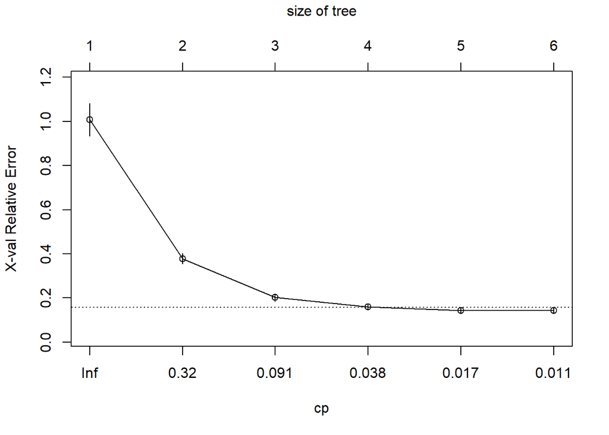

En analysant le graphe Plot cp, nous avons identifié une valeur optimale de cp comprise entre 0,26602 et 0,01, qui représente un bon compromis entre réduction de la déviance et limitation du nombre de partitions. Si nous avons une préférence de la complexité du modèle nous choisirons 0,026602 mais si nous voulons privilégé la prédiction nous choisirons 0,01. Dans la suite on utilisera 0,026602 qui permet d’éviter un arbre trop complexe tout en conservant une capacité prédictive satisfaisante.

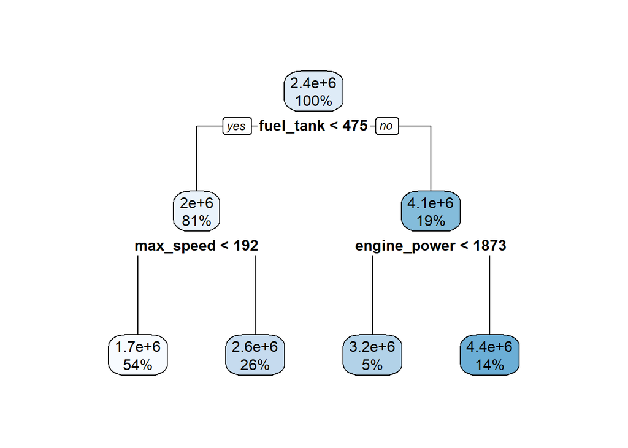

À partir de ce graphique, on peut déjà voir que les variables utilisées dans ce modèle CART optimal sont fuel_tank, max_speed et engine_power. Le reste des variables n’ont pas été sélectionnées dans l’arbre optimal et cela veut dire que selon le critère de déviance et le cp choisi, elles n’apportaient pas suffisamment d’information pour améliorer le modèle.

# Analyse comparative des régressions Ridge, Lasso et ElasticNet

## 1. Présentation des méthodes

Les régressions Ridge, Lasso et ElasticNet sont des méthodes de régression régularisées permettant d’améliorer la généralisation des modèles et de traiter les problèmes de multicolinéarité.

- **Régression Ridge** : Applique une pénalisation L2 ($\lambda \sum \beta_j^2$), réduisant l’amplitude des coefficients sans les annuler.
  - *Avantages* : Stabilise les coefficients, utile en présence de multicolinéarité.
  - *Inconvénients* : Ne permet pas de sélectionner automatiquement les variables pertinentes.
- **Régression Lasso** : Utilise une pénalisation L1 ($\lambda \sum |\beta_j|$), pouvant annuler certains coefficients.
  - *Avantages* : Sélectionne les variables les plus importantes, simplifie le modèle.
  - *Inconvénients* : Peut être instable si plusieurs variables sont corrélées.
- **ElasticNet** : Combine L1 et L2 avec deux paramètres :
  - $\lambda$ : Contrôle l’intensité de la pénalisation.
  - $\alpha$ : Équilibre entre L1 et L2 ($\alpha=1$ correspond à Lasso, $\alpha=0$ à Ridge, et $0<\alpha<1$ à ElasticNet).

## 2. Régression Ridge et colinéarité

La régression Ridge est particulièrement utile pour traiter la multicolinéarité en imposant une pénalisation sur les coefficients. Cela réduit leur variance et améliore la stabilité du modèle.

- **Effet du paramètre $\lambda$** :
  - Si $\lambda$ est trop faible, la régularisation est insuffisante.
  - Si $\lambda$ est trop élevé, le modèle devient trop rigide.

### Code pour extraire les coefficients Ridge en R :

```
## 16 x 1 sparse Matrix of class "dgCMatrix"
##                               s1
## (Intercept)         3.255845e+05
## engine_typePiston  -4.284587e+05
## engine_typePropjet -3.456240e+05
## engine_power        5.503115e+00
## max_speed           1.593834e+03
## cruise_speed        3.228423e+03
## stall_speed         5.924290e+03
## fuel_tank          -1.502786e+01
## all_eng_roc         5.105171e+01
## out_eng_roc         2.084763e+01
## takeoff_distance    9.237509e+01
## landing_distance   -1.172505e+01
## empty_weight       -7.778934e+00
## length              8.813283e+02
## wing_span           9.078243e+02
## range               1.487146e+02
```

## 3. Sélection de variables avec Lasso

La régression Lasso impose une pénalisation L1, pouvant annuler certains coefficients et ainsi sélectionner automatiquement les variables les plus pertinentes.

### Code pour extraire les variables sélectionnées en R :

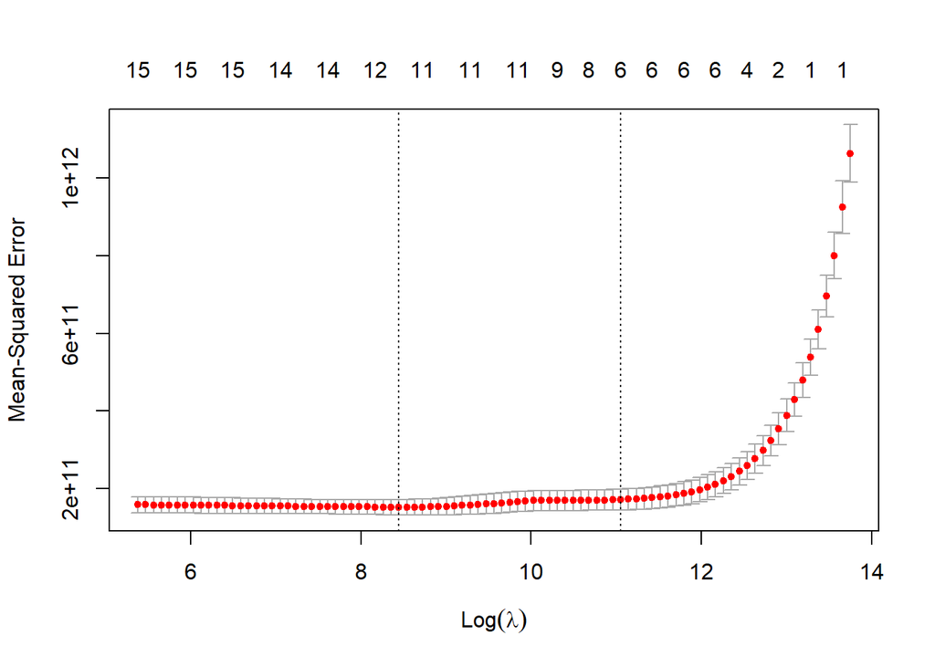

Cette approche est particulièrement utile dans un contexte de haute dimensionnalité, car elle permet de ne conserver que les variables ayant un réel pouvoir explicatif.

Comme mentionné précédemment, la régularisation imposée par le Lasso dépend du paramètre de pénalisation $\lambda$. Deux valeurs sont généralement considérées :

- **$\lambda_{\text{min}}$** : valeur minimisant l’erreur de validation croisée ;
- **$\lambda_{\text{1se}}$** : valeur la plus grande dont l’erreur reste dans un écart-type de la minimale.

Dans notre cas, nous choisissons **$\lambda_{\text{1se}}$**. Bien que ce choix puisse légèrement diminuer la performance prédictive, il permet de simplifier considérablement le modèle sans perte significative de précision. Cela nous garantit un modèle plus robuste et régularisé.

Ainsi, **6 variables explicatives** ont été sélectionnées avec ce réglage, contre 12 avec $\lambda_{\text{min}}$. Ces variables sont :

|  | Variable | Coefficient |
| --- | --- | --- |
| (Intercept) | (Intercept) | 753553.57942 |
| engine_typePiston | engine_typePiston | -228823.07715 |
| max_speed | max_speed | 1440.76820 |
| cruise_speed | cruise_speed | 5125.46119 |
| stall_speed | stall_speed | 3348.21118 |
| takeoff_distance | takeoff_distance | 74.38559 |
| length | length | 328.22132 |